# Intro to Data Science -Lab 08

##### Copyright 2021, Jeffrey Stanton, Jeffrey Saltz, and Jasmina Tacheva

```r
# Enter your name here:Pranav Sharma
```

### Attribution statement: (choose only one and delete the rest)

```r
# 1. I did this homework by myself, with help from the book and the professor.
#install.packages("maps")
##install.packages("mapproj")
#install.packages("ggmap")
library(maps)
library(mapproj)
library(ggmap)
library(MASS)
#install.packages("ggplot2")
#install.packages("ggplot2")
library(ggplot2)
```

1. Explore this dataset descrption by doing ?Boston at the command promt

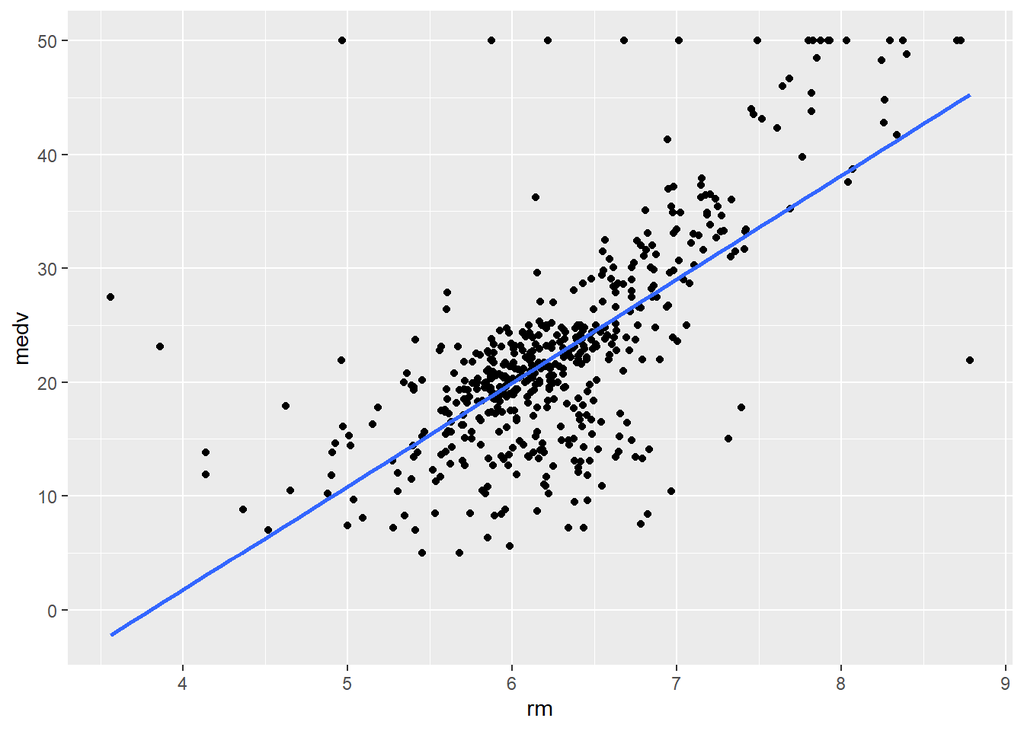

```r
Boston<- Boston
ggplot(data=Boston) + aes(x=rm, y=medv) + geom_point() + geom_smooth(method="lm", se=FALSE)
```

2. The graphic you just created fits a best line to a cloud of points. Copy and modify the code to produce a plot where “crim” is the x variable instead of “rm.”

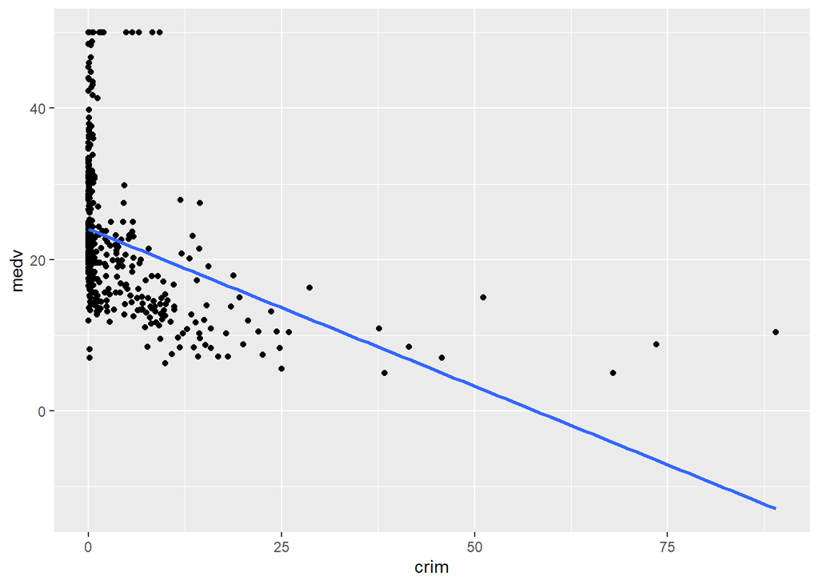

```r
plot1 <- ggplot(data=Boston) + aes(x=crim, y=medv) + geom_point() +
 geom_smooth(method="lm", se=FALSE)
plot1
```

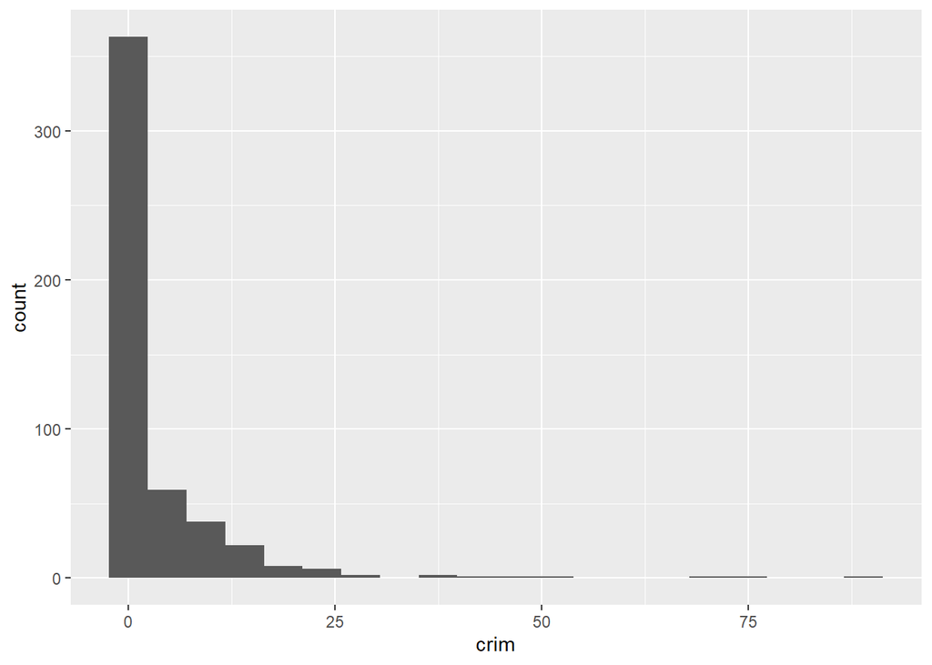

```r
ggplot(data=Boston,aes(crim)) +geom_histogram(bins=20)
```

```r
#hist(Boston$crim)
```

4. Produce a linear model, using the lm( ) function where crim predicts medv. Remember that in R’s formula language, the outcome variable comes first and is separated from the predictors by a tilde, like this: medv ~ crim Try to get in the habit of storing the output object that is produced by lm and other analysis procedures. For example, I often use lmOut <- lm( . . .

```r
lmOut <- lm(medv~crim ,data = Boston)
summary(lmOut)
```

```
##
## Call:
## lm(formula = medv ~ crim, data = Boston)
##
## Residuals:
##     Min      1Q  Median      3Q     Max
## -16.957  -5.449  -2.007   2.512  29.800
##
## Coefficients:
##             Estimate Std. Error t value Pr(>|t|)
## (Intercept) 24.03311    0.40914   58.74   <2e-16 ***
## crim        -0.41519    0.04389   -9.46   <2e-16 ***
## ---
## Signif. codes:  0 '***' 0.001 '**' 0.01 '*' 0.05 '.' 0.1 ' ' 1
##
## Residual standard error: 8.484 on 504 degrees of freedom
## Multiple R-squared:  0.1508, Adjusted R-squared:  0.1491
## F-statistic: 89.49 on 1 and 504 DF,  p-value: < 2.2e-16
```

5. Run a multiple regression where you use rm, crim, and dis (distance to Boston employment centers). You will use all three predictors in one model with this formula: medv ~ crim + rm + dis. Now run three separate models for each independent variable separate.

```r
lmReg <- lm(medv ~ crim + rm + dis, data=Boston)

#
lmReg2<- lm(medv ~ crim,data=Boston)
lmReg3<-lm(medv ~ rm,data=Boston)
lmReg4<- lm(medv ~ dis,data=Boston)
```

6. Interpret the results of your analysis in a comment. Make sure to mention the pvalue, the adjusted R-squared, the list of significant predictors and the coefficient for each significant predictor.

```r
summary(lmReg)
```

```
##
## Call:
## lm(formula = medv ~ crim + rm + dis, data = Boston)
##
## Residuals:
##     Min      1Q  Median      3Q     Max
## -21.247  -2.930  -0.572   2.390  39.072
##
## Coefficients:
##              Estimate Std. Error t value Pr(>|t|)
## (Intercept) -29.45838    2.60010 -11.330  < 2e-16 ***
## crim         -0.25405    0.03532  -7.193 2.32e-12 ***
## rm            8.34257    0.40870  20.413  < 2e-16 ***
## dis           0.12627    0.14382   0.878     0.38
## ---
## Signif. codes:  0 '***' 0.001 '**' 0.01 '*' 0.05 '.' 0.1 ' ' 1
##
## Residual standard error: 6.238 on 502 degrees of freedom
## Multiple R-squared:  0.5427, Adjusted R-squared:  0.5399
## F-statistic: 198.6 on 3 and 502 DF,  p-value: < 2.2e-16
```

```r
#adjusting R2 rate is 0.5399,pvalue is < 2.2e-16.
#Significant Predictors (Intercept)=> 2e-16,crim=> 2.32e-12,rm=> 2e-16 ; Coefficient ->  Pr(>|t|)
summary(lmReg2)
```

```
##
## Call:
## lm(formula = medv ~ crim, data = Boston)
##
## Residuals:
##     Min      1Q  Median      3Q     Max
## -16.957  -5.449  -2.007   2.512  29.800
##
## Coefficients:
##             Estimate Std. Error t value Pr(>|t|)
## (Intercept) 24.03311    0.40914   58.74   <2e-16 ***
## crim        -0.41519    0.04389   -9.46   <2e-16 ***
## ---
## Signif. codes:  0 '***' 0.001 '**' 0.01 '*' 0.05 '.' 0.1 ' ' 1
##
## Residual standard error: 8.484 on 504 degrees of freedom
## Multiple R-squared:  0.1508, Adjusted R-squared:  0.1491
## F-statistic: 89.49 on 1 and 504 DF,  p-value: < 2.2e-16
```

```r
#adjusting R2 rate is 0.1491,pvalue is < 2.2e-16
#Significant Predictors crim=> 2.2e-16,(Intercept)=> 2e-16; Coefficient->  Pr(>|t|)
summary(lmReg3)
```

```
##
## Call:
## lm(formula = medv ~ rm, data = Boston)
##
## Residuals:
##     Min      1Q  Median      3Q     Max
## -23.346  -2.547   0.090   2.986  39.433
##
## Coefficients:
##             Estimate Std. Error t value Pr(>|t|)
## (Intercept)  -34.671      2.650  -13.08   <2e-16 ***
## rm             9.102      0.419   21.72   <2e-16 ***
## ---
## Signif. codes:  0 '***' 0.001 '**' 0.01 '*' 0.05 '.' 0.1 ' ' 1
##
## Residual standard error: 6.616 on 504 degrees of freedom
## Multiple R-squared:  0.4835, Adjusted R-squared:  0.4825
## F-statistic: 471.8 on 1 and 504 DF,  p-value: < 2.2e-16
```

```r
#adjusting R2 rate is 0.4825,pvalue is < 2e-16.
#Significant Predictors (Intercept)=> 2e-16,rm=> 2e-16;  Coefficient->  Pr(>|t|)
summary(lmReg4)
```

```
##
## Call:
## lm(formula = medv ~ dis, data = Boston)
##
## Residuals:
##     Min      1Q  Median      3Q     Max
## -15.016  -5.556  -1.865   2.288  30.377
##
## Coefficients:
##             Estimate Std. Error t value Pr(>|t|)
## (Intercept)  18.3901     0.8174  22.499  < 2e-16 ***
## dis           1.0916     0.1884   5.795 1.21e-08 ***
## ---
## Signif. codes:  0 '***' 0.001 '**' 0.01 '*' 0.05 '.' 0.1 ' ' 1
##
## Residual standard error: 8.914 on 504 degrees of freedom
## Multiple R-squared:  0.06246,    Adjusted R-squared:  0.0606
## F-statistic: 33.58 on 1 and 504 DF,  p-value: 1.207e-08
```

```r
#adjusting R2 rate is 0.0606,pvalue is 1.207e-08.
#Significant Predictors (Intercept) => 2e-16, dis=> 1.21e-08;Coefficient->  Pr(>|t|)
```

7. Create a one-row data frame that contains some plausible values for the predictors. For example, this data frame contains the median values for each predictor: predDF <- data.frame(crim = 0.26, dis=3.2, rm=6.2) The numbers used here were selected randomly by looking at min and max data of the variables.

```r
predDF <- data.frame(crim = 0.3, dis=3.3, rm=6.1)
```

8. Use the predict( ) command to predict a new value of medv from the onerow data frame. If you stored the output of your lm model in lmOut, the command would look like this: predict(lmOut, predDF)

```r
predict(lmOut,predDF)
```

```
##        1
## 23.90855
```